# Summer 2022 Data Science Intern Challenge Q1

Alvin Yap

January 14, 2022

#### On Shopify, we have exactly 100 sneaker shops, and each of these shops sells only one model of shoe. We want to do some analysis of the average order value (AOV). When we look at orders data over a 30-day window, we naively calculate an AOV of $3145.13. Given that we know these shops are selling sneakers, a relatively affordable item, something seems wrong with our analysis.

This webpage will walk you through my work and thought process as I go through the following dataset: (https://docs.google.com/spreadsheets/d/16i38oonuX1y1g7C_UAmiK9GkY7cS-64DfiDMNiR41LM/edit#gid=0)

The python and the Jupyter notebook version of this solution can be found at:https://github.com/AlvinSJYap/ShopifyDataScienceInternChallenge

## Step 1: Import Dataset into a data frame

```r
raw_df <- read_csv("./RawData/DataScienceDataSet1.csv")
colnames(raw_df)
```

```
## [1] "order_id"       "shop_id"        "user_id"        "order_amount"
## [5] "total_items"    "payment_method" "created_at"
```

## Step 2: Data Exploration

My initial thought on why AOV is wrong in the above analysis is because they are using the Mean of ‘order_amount’. To verify, let us take a look at a statistical summary of the dataset.

```r
summary(raw_df)
```

```
##     order_id       shop_id          user_id       order_amount
##  Min.   :   1   Min.   :  1.00   Min.   :607.0   Min.   :    90
##  1st Qu.:1251   1st Qu.: 24.00   1st Qu.:775.0   1st Qu.:   163
##  Median :2500   Median : 50.00   Median :849.0   Median :   284
##  Mean   :2500   Mean   : 50.08   Mean   :849.1   Mean   :  3145
##  3rd Qu.:3750   3rd Qu.: 75.00   3rd Qu.:925.0   3rd Qu.:   390
##  Max.   :5000   Max.   :100.00   Max.   :999.0   Max.   :704000
##   total_items       payment_method      created_at
##  Min.   :   1.000   Length:5000        Length:5000
##  1st Qu.:   1.000   Class :character   Class :character
##  Median :   2.000   Mode  :character   Mode  :character
##  Mean   :   8.787
##  3rd Qu.:   3.000
##  Max.   :2000.000
```

We can see that the mean value for the ‘order_amount’ column matches the above AOV at $3145. This is a gross overestimation of the AOV. The median would be a better metric if we were to use this data set without any cleaning.

```
## [1] "Variance of order_amount:  1704248055.08423"
```

```
## [1] "Standard Deviation of order_amount:  41282.539348788"
```

```
## [1] "Coeffcient of variation of order_amount:  1312.58693918938 %"
```

As you can see, there is a large amount of variance as indicated by the coefficient of variation and the standard deviation of order_amount. This will negatively impact the accuracy of our AOV if we use the current mean as the metric to measure.

## Box Plot of Pre-cleaned Data Set

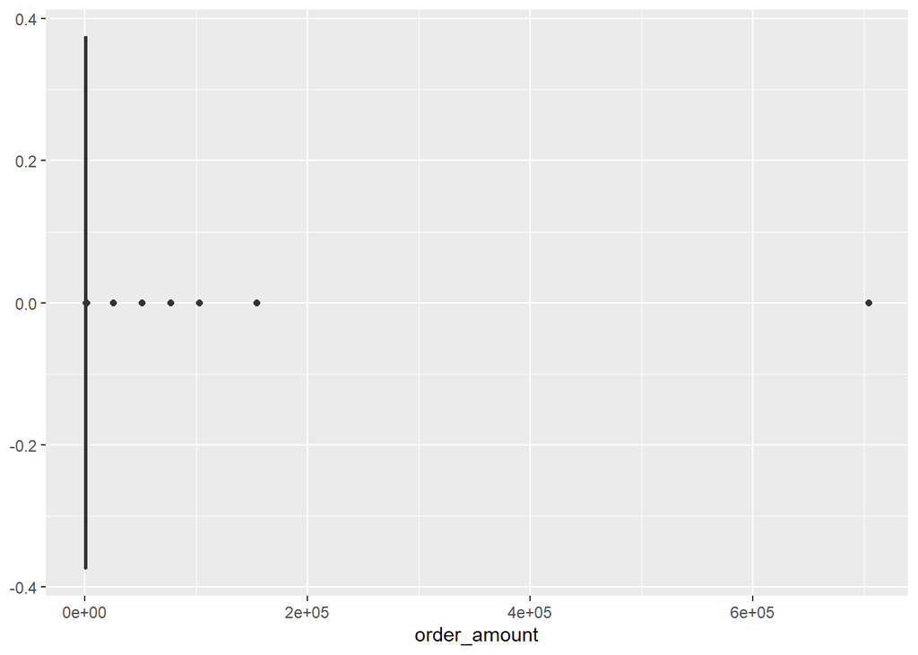

## Step 3: Data Cleaning

From the box plot, we have some clear outliers that are causing issues with our analysis. Following statistical convention, we will calculate the Interquartile Range (IQR) and anything outside q3 + 1.5 * IQR or q1 - 1.5 *IQR will be discarded.

```r
upperBound <- quantile(raw_df$order_amount,0.75) + (IQR(raw_df$order_amount) * 1.5)
lowerBound <- quantile(raw_df$order_amount,0.25) - (IQR(raw_df$order_amount) * 1.5)
cleaned_df<-subset(raw_df,raw_df$order_amount>lowerBound & raw_df$order_amount<upperBound)
summary(cleaned_df)
```

```
##     order_id       shop_id          user_id       order_amount
##  Min.   :   1   Min.   :  1.00   Min.   :700.0   Min.   : 90.0
##  1st Qu.:1244   1st Qu.: 24.00   1st Qu.:776.0   1st Qu.:162.0
##  Median :2498   Median : 50.00   Median :850.0   Median :280.0
##  Mean   :2497   Mean   : 49.85   Mean   :849.9   Mean   :293.7
##  3rd Qu.:3750   3rd Qu.: 74.00   3rd Qu.:925.0   3rd Qu.:380.0
##  Max.   :5000   Max.   :100.00   Max.   :999.0   Max.   :730.0
##   total_items   payment_method      created_at
##  Min.   :1.00   Length:4859        Length:4859
##  1st Qu.:1.00   Class :character   Class :character
##  Median :2.00   Mode  :character   Mode  :character
##  Mean   :1.95
##  3rd Qu.:3.00
##  Max.   :5.00
```

The cleaning process reduces the # of entries from 5000 to 4859 meaning 141 entries were considered outliers. Using the above summary, we can see that the mean has become a much more realistic number at $293.7 and is much better suited to being the metric to measure AOV. As you can see below, our boxplot is much improved alongside our statistical measurements of variance, standard deviation, and the coefficient of variation.

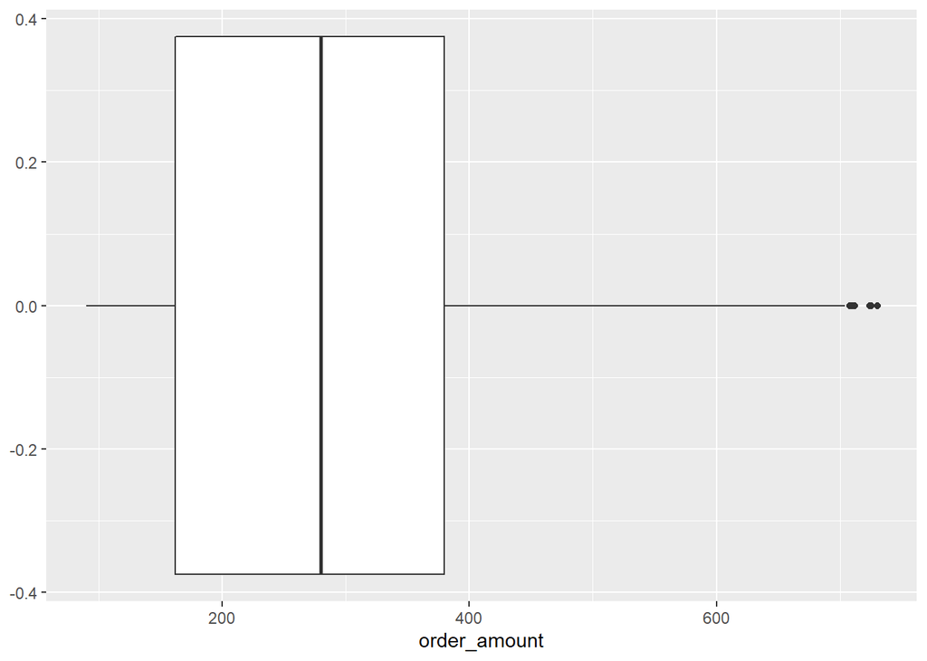

```
## [1] "Variance of order_amount:  20866.7833185667"
```

```
## [1] "Standard Deviation of order_amount:  144.45339497072"
```

```
## [1] "Coeffcient of variation of order_amount:  49.1814211945465 %"
```

# Conclusion

The answers to questions for this challenge are as follows:

**a. Think about what could be going wrong with our calculation. Think about a better way to evaluate this data.**

**Answer:** What went wrong with the AOV calculation was the usage of Mean as the metric. Mean is sensitive to outliers and it can cause the data average to skew in ways that cause errors in analysis. We can evaluate the AOV in better ways by either cleaning the data first and removing the outliers before using the mean, or we can use the median value if we do not have time to clean the data.

**b. What metric would you report for this dataset?**

**Answer:** The metric I would report for this dataset would be a mean that is based on the cleaned data where the initial outliers are removed. This would give us a more accurate depiction of the AOV for our 100 sneaker shops. If data points that would normally be considered statistical outliers must be kept in, the median would be a valid metric to report for this data set.

**c. What is its value?**

**Answer:** The metric to calculate the AOV is the mean of the data after removing outliers: $293.72. Alternatively, if the data is to not be modified in any manner, then we will use the median of the original data set thus the AOV would be: $284.0.